# Evaluate the Arsenal of TI methods: CRISPR, OMICS, and compound screening

```r
library(data.table)
```

## Objective:

> To evaluate 3 target identification methods: CRISPR, compound screening, OMIC expression profiling.

## Compound screening

> With a well suited functional readout, this is the most efficient target ID method because of its pharmacological nature. However, existing compound libaries are neither complete nor well annotated. This represents a big limitation of this method.

> It is possible to exatropolate individual target genes to pathways by using pathway databases such as the KEGG and STRING, understanding that the pathway databases are generally deprived of cell and context specificity. There might be a way to prune the pathway databases (KEGG and STRING) to the more conservative components.

## The LKB1 project run a cell survival assay on 21 lung cancer cell lines using a small library of 54 compounds that are annotated to 42 target genes.

> Brian Anderson selected the 54 compounds, which covers the LKB1 pathway inhibitors, adjacent pathway inhibitors, standards of cares, GDSC and Achilles genetic targets.

```r
paste("Number of unique compounds:", length(unique(ctg$Sample)))
```

```
[1] "Number of unique compounds: 54"
```

| Sample | target |
| --- | --- |
| L-001748230-001Y002 | ACC 1/2 |
| L-006375236-000J001 | ACC 1/2 |
| L-001948211-003H001 | AKT 1 |
| L-006369882-000J002 | ALK |
| L-004925451-000T006 | AMPK |
| L-000572059-001X009 | ampk activator |
| L-000657335-000C019 | AMPK/VDAC1 |
| L-005131606-001U004 | antifolate chemotherapeutic |
| L-006308651-000Z001 | CAMKII |
| L-002486963-000N032 | CDK 2, 5, 1, 9 |

[output cut: 44 more lines]

## The compound screening experiment run two replicates for each compound and cell combo.

## What about consistency bt the two replicates?

```r
table(is.na(ctg$dispense))
```

```
FALSE  TRUE
   23  1111
```

## But, there are multiple outliers, which we exclude from downstream analysis.

```r
paste("Compounds:", unique(ctg1$Sample))
```

```
 [1] "Compounds: L-000572059-001X009" "Compounds: L-000657335-000C019" "Compounds: L-000728614-000U013"
 [4] "Compounds: L-001748230-001Y002" "Compounds: L-001948211-003H001" "Compounds: L-001986937-000Z002"
 [7] "Compounds: L-001998390-000M004" "Compounds: L-002114116-000B003" "Compounds: L-002135210-000G005"
[10] "Compounds: L-002486963-000N032" "Compounds: L-002488444-000C005" "Compounds: L-002952254-000G006"
[13] "Compounds: L-004925451-000T006" "Compounds: L-005131606-001U004" "Compounds: L-006059585-000G002"
[16] "Compounds: L-006337660-000F001" "Compounds: L-006340309-000C001" "Compounds: L-006369882-000J002"
```

> 23 compound and cell combo showed poor consistency between the replicates: 10 times or greater in EC50 ratio. The 23 compound/cell combo spread to 18 compounds on 7 cells, no pattern in terms which compounds or cells were more prone to generate the inconsistent results

## Take the average of the two EC50 values per compound and cell combo for the downstream analysis

```r
summary(ctg$ec50)
```

```
     Min.   1st Qu.    Median      Mean   3rd Qu.      Max.
    0.508   128.045  6405.704  5353.959 10000.000 10000.000
```

## Let’s break down the 54 compounds into 3 groups: (1) no effects in all cells; (2) strong effects in all cells; (3) variable effects across the cells

```r
dim(cs3)
```

```
[1] 34 10
```

## What the EC50 data looks like for compounds that showed no effects in all cells?

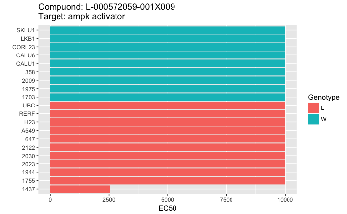

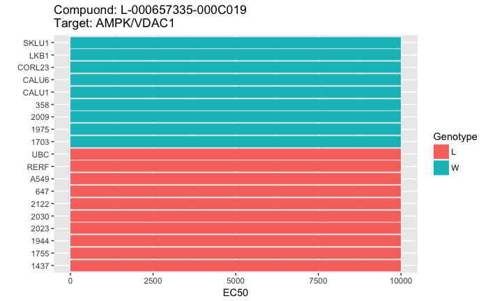

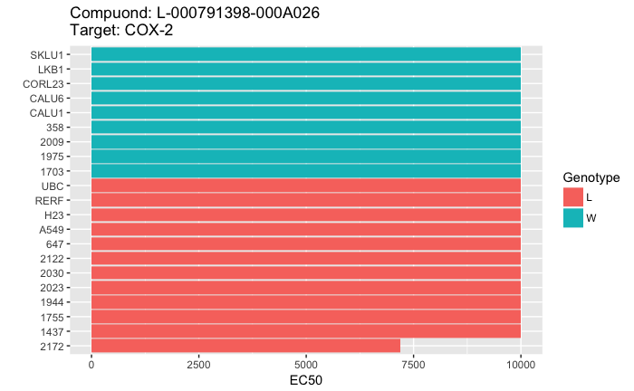

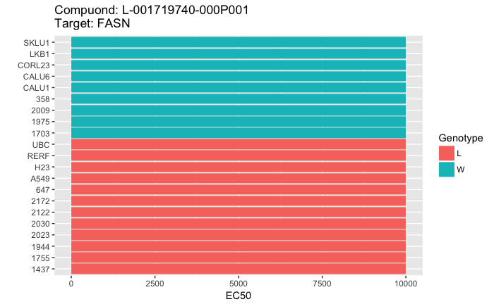

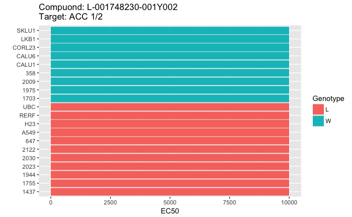

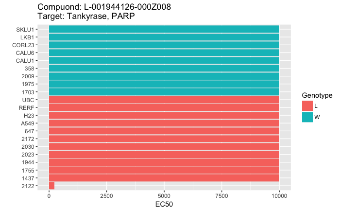

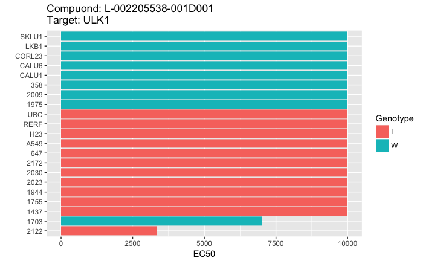

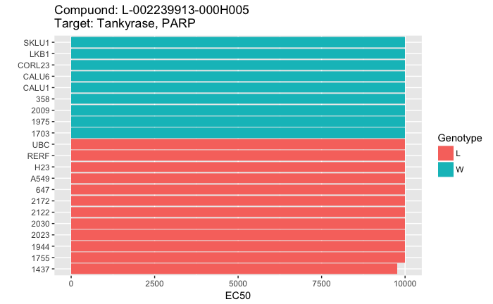

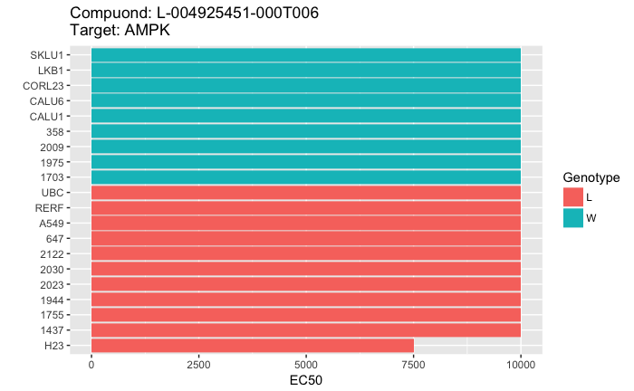

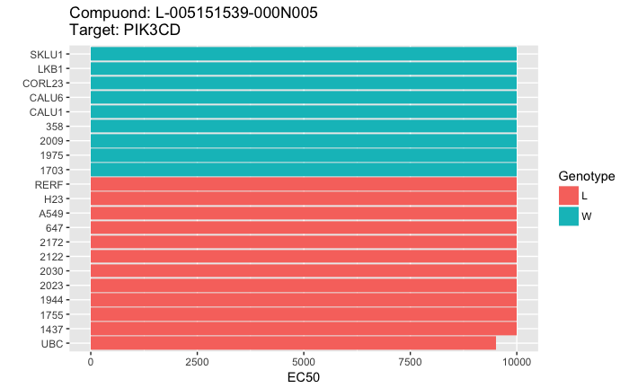

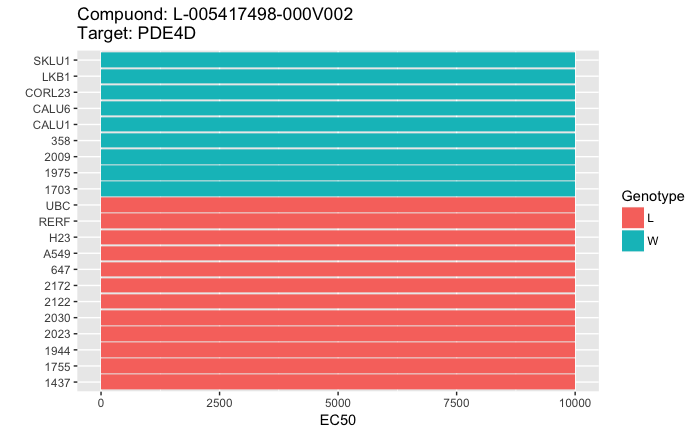

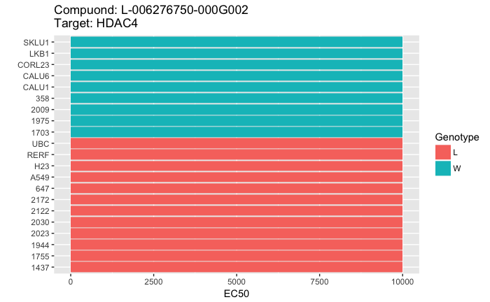

[3 more figures not shown]

## Mapping compounds to target genes

> To compare w CRISPR results, we removed activating compounds: AMPK activators After mapping compounds to target genes, there are plenty of 1 to N and N to 1 mapping from compound to target genes. The 12 no-effects compounds map to 12 unique genes, which forms the no-effects gene list. Among the 12 target genes, there are other compounds that target HDAC4 and PIK3CD and showed some effects. We removed these two genes from the no-effects gene list.

```r
(mygene3 = setdiff(mygene2, c("HDAC4", "PIK3CD")))
```

[output not shown]

## Now, let’s look at the CRISPR data on these 10 genes

## 12 out of the 21 compound screening cell lines had CRISPR data in Achilles

```r
intersect(z1, z2)
```

```
 [1] "A549"     "CALU1"    "CALU6"    "CORL23"   "NCIH1437" "NCIH1703" "NCIH1944" "NCIH2023" "NCIH2030"
[10] "NCIH2122" "NCIH2172" "NCIH23"
```

## 10 out of the 10 genes had Achilles results

```r
intersect(mygene3, rownames(achille2))
```

[output not shown]

## Do CRISPR and compound screening results agree with each other?

```r
y = achille2[mygene3, ]

hc1 = hcluster(y, method = "pearson", link = "average")
hc2 = hcluster(t(y), method = "pearson", link = "average")

y = y[hc1$order, hc2$order]
gdt <- melt(as.matrix(y))

gdt$gene <- factor(gdt$Var1, levels = rownames(y))
gdt$cell <- factor(gdt$Var2, levels = colnames(y))

ggplot(gdt, aes(x = gene, y = cell, fill = value)) +
  geom_tile() + guides(alpha = F) +
  scale_fill_gradient2(low = "blue", high = "red") +
  theme_bw() + xlab("") + ylab("") +
  theme(axis.text.x = element_text(angle = 90, hjust = 1))
```

[output not shown]

```r
y1 = achille2
y2 = achille2[mygene3, ]

table(y1 > 0.5) / nrow(y1) / ncol(y1)
table(y2 > 0.5) / nrow(y2) / ncol(y2)

y1m = melt(as.matrix(y1))
y2m = melt(as.matrix(y2))

y1m$ID = paste(y1m$Var1, y1m$Var2, sep = "_")
y2m$ID = paste(y2m$Var1, y2m$Var2, sep = "_")

y3 = data.frame(ID = y1m$ID, pp = y1m$value)
y3$bpp = as.numeric(y3$pp < 0.5)
y3$cs = as.numeric(y3$ID %in% y2m$ID)

glm(data = y3, bpp ~ cs, family = "binomial") %>% summary
y4 = with(y3, table(bpp, cs))
chisq.test(y4)$p.value
```

[output not shown]

## What the OMICS data looks like for these genes?

```r
load("~/Desktop/myproject/total_protein.rdt")
hist(expr2)

expr3 = expr2[gsub("_.*", "", rownames(expr2)) %in% mygene3, ]
quantile(expr2, c(0.1, 0.3, 0.5))
quantile(expr3, c(0.1, 0.3, 0.5))
```

[output not shown]

## What the EC50 data looks like for compounds that showed strong effects in all cells?

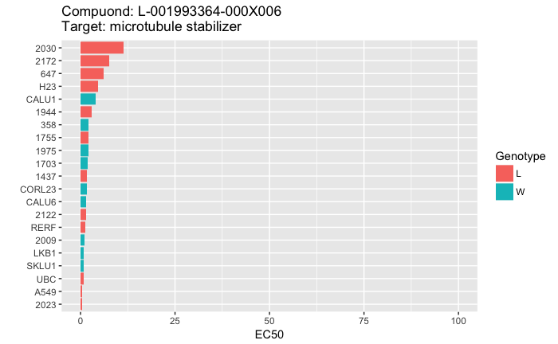

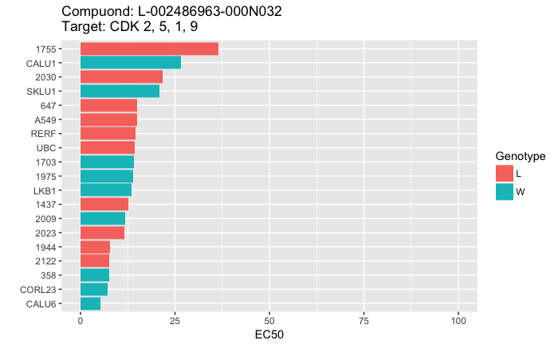

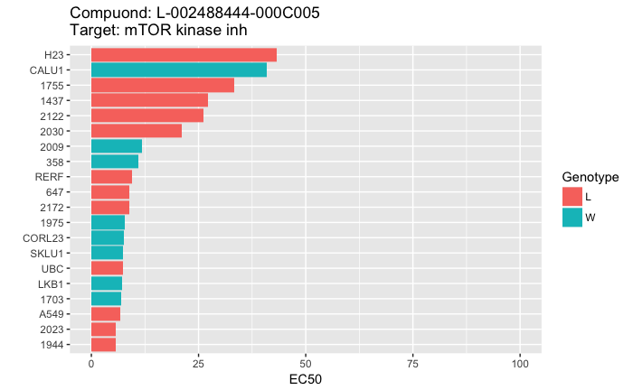

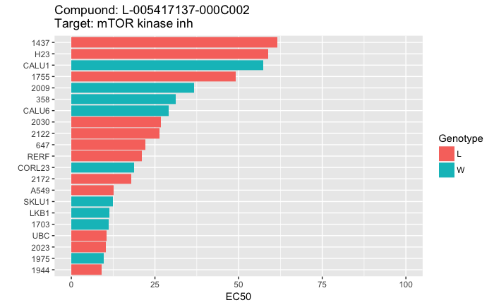

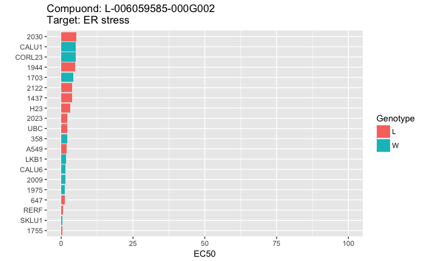

## Annotate the compound targets

```r
mygene1 = sapply(mytable1$Target_gene, function(x) unlist(strsplit(x, split = ", ")))
```

[output not shown]

## Do CRISPR and compound screening results agree with each other?

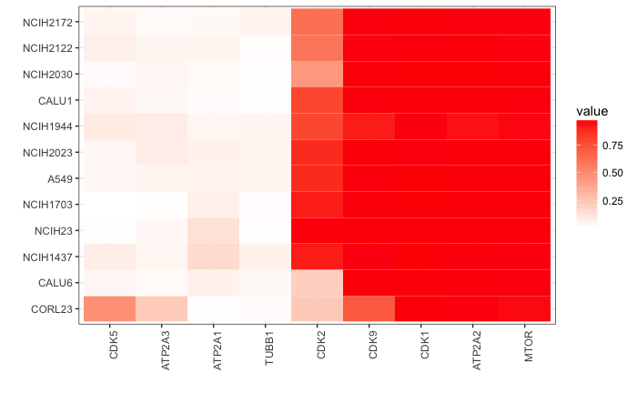

## Test: what is the odds ratio of the 9 genes to have dependency probability larger than 0.5

```r
chisq.test(y4)$p.value
```

```
[1] 1.170379e-40
```

## What the EC50 data looks like for compounds that showed variable effects across the cells?

```r
for ( cmpd1 in rownames(cs3)) {
  ctg1 = ctg[ctg$Sample == cmpd1, ]
  ctg1 = ctg1[order(ctg1$ec50), ]
  ctg1$Cells = factor(ctg1$Cells, levels = ctg1$Cells)

  wilcox = wilcox.test(ec50 ~ Genotype, data = ctg1)
  pval = format(wilcox$p.value, digits = 3)
  target = unique(ctg1$target)
  mytitle = paste0("Compuond: ", cmpd1, "\n", "Target: ", target, "\n", "P-value: ", pval)
  p = ggplot(ctg1, aes(x = Cells , y = ec50, fill = Genotype)) + geom_bar(stat = "identity") +
    coord_flip() + xlab("") + ylab("EC50") + ggtitle(mytitle) # + ylim(c(0, 1e2))
  print(p)
}
```

[output not shown]

## Mapping compounds to target genes

```r
mytable2 = xlsx::read.xlsx("myeval.xlsx", sheetName = "Table 1")
mytable4 = mytable2[mytable2$Compound_effect == "variable effects", ]
mytable4 = mytable4[! is.na(mytable4$Target_gene), ]
mygene4 = sapply(mytable4$Target_gene, function(x) unlist(strsplit(x, split = ", ")))
mygene5 = unique(unlist(mygene4))
```

## Resolved 15 target genes for the 34 compounds that showed variable effects across the cells

```r
intersect(mygene5, rownames(achille2))
```

[output not shown]

## Among these 15 genes, what about the concordance between the compound screening and Achilles results?

```r
names(mygene4) = mytable4$Compound
zzz = do.call(rbind, mygene4) %>% melt
mytable5 = zzz[! duplicated(paste(zzz$Var1, zzz$value, sep = "_")), ]
mytable5$Var2 = NULL
names(mytable5) = c("Compound", "Target_gene")
mytable5$Target = mytable4$Target[match(mytable5$Compound, mytable4$Compound)]

mytable5 = mytable5[mytable5$Target_gene %in% rownames(achille2), ]

x = ctg[ctg$Sample %in% mytable5$Compound, ]
x = x[x$Cells %in% colnames(achille2), ] # cpd screening results
y = achille2[unique(mytable5$Target_gene), ] # achilles results

cor_all = lapply( 1:nrow(mytable5), function(i) {
  x1 = x[x$Sample == mytable5$Compound[i], ]
  y1 = y[mytable5$Target_gene[i], x1$Cells]

  x1$PP = 1 - c(as.matrix(y1)) # high dependency probability maps to low EC50
  cor = cor.test(x1$ec50, x1$PP)
  pho = format(cor$estimate, digits = 3)
  pval = format(cor$p.value, digits = 3)
  data.frame(Cor = pho, Pval = pval)
})

mytable5 = cbind(mytable5, do.call(rbind, cor_all))
data.table(mytable5)
```

[output not shown]

```r
for ( i in 1:nrow(mytable5)) {
  cmpd1 = mytable5$Compound[i]
  target = mytable5$Target_gene[i]
  x1 = x[x$Sample == cmpd1, ]
  y1 = y[target, x1$Cells]

  x1$PP = 1 - c(as.matrix(y1)) # high dependency probability maps to low EC50
  cor = cor.test(x1$ec50, x1$PP)
  pho2 = format(cor$estimate, digits = 3)
  pval = format(cor$p.value, digits = 3)

  cor = cor.test(x1$ec50, x1$PP)
  cor = format(cor$estimate, digits = 3)
  mytitle = paste0("Compuond: ", cmpd1, "\n", "Target: ", target, "\n", "Cor: ", pho2, "\n", "P-value: ", pval)
  p = ggplot(x1, aes(x = ec50, y = PP)) + geom_point() +
    xlab("Screening EC50") + ylab("1 - Achilles Dependency Probability") + ggtitle(mytitle)
  print(p)
}
```

[output not shown]

## Starting from the compound screening results, ask what the CRISPR data looks like

## Two ways to compare the CRISPR and compound screening results

1. Single gene > take genes w variability, run correlation between the CS EC50 and the CRISPR dependency probability > take genes that showed LKB1 synthetic dependency, test the contingency table (need to choose a cutoff)
2. Across many genes > Absolute EC50 values are not comparable among different compounds, a normalization is needed > probably now a practical analysis

## Starting from the CRISPR data, ask what the compound screening data looks like?

## CRISPR experiment by Achilles only depleted genes.

## It estimated, for active/expressed genes in a given cell line, the survival dependency to a given gene for a given cell (dependency probability).